# CS 611 Time Series Analysis Final Exam

Evan Walker

5/12/2019

```r
library(aTSA)
library(TSA)
library(TTR)
library(quantmod)
library(forecast)
library(knitr)
```

### Problem 1) We want to use our knowledge of ARIMA and Holt-Winters models to invest successfully. Download (https://finance.yahoo.com/) the daily closing stock prices of Facebook, Apple, Intel, IBM, Nvidia, Sirius, Spotify, Google, Amazon, Wells- Fargo, GE, Ebay, Sprint, Verizon, Walt Disney, Nike, Netflix, Walmart, Tesla, and Target for the last 5 years, read the datasets into R and convert the variables into time series objects using the ts() command in R.

#### a) We want to see how often various ARIMA models were appropriate for these stocks (ARIMA(0,0,1), ARIMA(1,0,0), etc). Split each stock in non-overlapping windows of 100 and find the best model for each window (use auto.arima() in the package forecast). Create a frequency table that displays the number of times a particular ARIMA model was selected.

```r
start=as.Date("2014-05-11")
end=as.Date("2019-05-11")
stocks=c("FB","AAPL","IBM","NVDA","SIRI","SPOT","GOOGL","AMZN","WFC",
         "GE","EBAY","S","VERI","DIS","NKE","NFLX","WMT","TSLA","TGT")

for (i in stocks) {
  getSymbols(i,src="yahoo",from=start,to=end)
}
```

[output not shown]

```r
AllStocks=list(
  fb=ts(FB$FB.Close),
  apl=ts(AAPL$AAPL.Close),
  ibm=ts(IBM$IBM.Close),
  nvda=ts(NVDA$NVDA.Close),
  siri=ts(SIRI$SIRI.Close),
  spot=ts(SPOT$SPOT.Close),
  googl=ts(GOOGL$GOOGL.Close),
  amzn=ts(AMZN$AMZN.Close),
  wfc=ts(WFC$WFC.Close),
  ge=ts(GE$GE.Close),
  ebay=ts(EBAY$EBAY.Close),
  sprt=ts(S$S.Close),
  veri=ts(VERI$VERI.Close),
  dsny=ts(DIS$DIS.Close),
  nke=ts(NKE$NKE.Close),
  nflx=ts(NFLX$NFLX.Close),
  wlmt=ts(WMT$WMT.Close),
  tsla=ts(TSLA$TSLA.Close),
  trgt=ts(TGT$TGT.Close)
)

#args: stock closing time series
#out: (list) od mods
#od- is the order of the arima model in the form "pdq" for all windows of 100, in chronological order
#mods- is all arima models in a list in order of windows of 100 increasing
#freq- frequency table of arima orders
windowArimaOrder<-function(stk){
  end=floor(length(stk)/100)
  window=100
  upper=window+1
  lower=1
  windows=NULL
  mods=vector("list",end)
  for (i in 1:end) {
    stk_mod=auto.arima(stk[lower:upper])
    mods[[i]]=stk_mod
    windows=c(windows,paste0(lower,"-",upper))
    upper=upper+window
    lower=lower+window
  }
  orders=sapply(mods,arimaorder)
  od=apply(orders,MARGIN=2,function(z) gsub(", ","",toString(z)))
  freq=table(od)
  od=rbind(windows,od)
  return(list(freq,od,mods))
}
AllStock_tableOrder= sapply(AllStocks,function(z) windowArimaOrder(z)[[1]])
AllStock_tableOrder
```

```
## $fb
## od
## 010 101 212
##  10   1   1
##
## $apl
## od
## 010 011 021 100
##   7   1   1   3
##
## $ibm
## od
## 010 021 212
##  10   1   1
##
## $nvda
## od
## 010 100 112 212
##   9   1   1   1
##
## $siri
## od
## 010 100
##  10   2
##
## $spot
## od
## 010
##   2
##
## $googl
## od
## 010 013 100 104 411
##   8   1   1   1   1
##
## $amzn
## od
## 010 011
##  11   1
##
```

[output cut: 39 more lines]

```
##
## $wlmt
## od
## 010 011 100 111
##   7   3   1   1
##
## $tsla
## od
## 010 100 122
##   9   2   1
##
## $trgt
## od
## 010 011 012 100
##   8   2   1   1
```

In all cases, p=0, d=1, q=0 was the most frequent model of choice, signifying that stocks are often random walks

#### b) Focus on the last 200 days of the data. Find the best ARIMA and Holt-Winters models for each stock using days 200 to 101 and forecast the value for day 100. Compare it to the actual value at day 100. If the direction of the forecasted value and the true value were the same (compared to day 101), count this as a successful forecast (as you can make money on it). Shift the window one day to the right and redo the analysis. Keep shifting the window until you forecast day 1 using days 101 to 2. Summarize the results by reporting the percent of time (for ARIMA and HW) you had a successful forecast for each stock over the last 100 trading days (55% or higher is considered good for investing).

```r
#eval=F
windowsuccess<-function(stk){
  stk=stk[(length(stk)-200):length(stk)]
  window=100
  upper=window
  lower=1
  windows=NULL
  end=upper

  data=data.frame(holts_success=character(),arima_success=character())
  for (i in 1:end) {
    actual=stk[(upper+1)]
    prev=stk[upper]

    stk_mod_arima=auto.arima(stk[lower:upper])
    arima=forecast(stk_mod_arima,h=1)$mean[[1]]

    stk_mod_holt=HoltWinters(stk[lower:upper],gamma=F,beta=F)
    holts=forecast(stk_mod_holt,h=1)$mean[[1]]

    windows=paste0(lower,"-",upper)

    tmp_holt = ifelse(((actual >= prev) & (holts >= prev))|((actual <= prev) & (holts <= prev)),
                          "success", "failure")

    tmp_arima= ifelse(((actual >= prev) & (arima >= prev))|((actual <= prev) & (arima <= prev)),
                          "success", "failure")
    tmp=data.frame(holts_success=tmp_holt,arima_success=tmp_arima)

    data=rbind(data,tmp)

    upper=upper+1
    lower=lower+1
  }
  h=as.vector(table(data$holts_success))
  a=as.vector(table(data$arima_success))
  return(list(holts_suc=h[1],holts_fail=h[2],arima_suc=a[1],arima_fail=a[2]))
}
AllStock_holt_arima= t(sapply(AllStocks,simplify=T,windowsuccess))
AllStock_holt_arima
```

```
##       holts_suc holts_fail arima_suc arima_fail
## fb    52        48         90        10
## apl   45        55         84        16
## ibm   46        54         81        19
## nvda  46        54         78        22
## siri  47        53         86        14
## spot  58        42         82        18
## googl 38        62         81        19
## amzn  54        46         92        8
## wfc   42        58         77        23
## ge    50        50         72        28
## ebay  53        47         73        27
## sprt  55        45         84        16
## veri  51        49         77        23
## dsny  47        53         91        9
## nke   38        62         51        49
## nflx  54        46         100       NA
## wlmt  52        48         90        10
## tsla  48        52         95        5
## trgt  63        37         15        85
```

```r
d=apply(AllStock_holt_arima,MARGIN = 2,as.numeric)
d[is.na(d)] <- 0
colSums(d)
```

```
##  holts_suc holts_fail  arima_suc arima_fail
##        939        961       1499        401
```

```r
prop.table(colSums(d[,c(1,2)]))
```

```
##  holts_suc holts_fail
##  0.4942105  0.5057895
```

```r
prop.table(colSums(d[,c(3,4)]))
```

```
##  arima_suc arima_fail
##  0.7889474  0.2110526
```

Holts has roughly 50% failure and 50% success, Arima has roughly 80% success and 20% failure.

### Problem 2) Consider the classical random walk with absorbing barriers at 0 and N (gambler’s ruin) where a gambler starts with k dollars, bets 1 dollar at each step, wins 1 dollar with probability p and loses his 1 dollar stake with probability q=1-p; he either wins (N-k) dollars to get his fortune to N dollars (the random walk gets absorbed at barrier N) and buys a car or goes bankrupt and quits (the random walk gets absorbed at barrier 0). Find the average number of the random walk steps until hitting the absorbing barriers.

Let $D_{k}$ be the average number of steps until getting absorbed by barriers starting with $k$ dollars. Using,
$$E(X)=E_{Y}(E_{X}(X|Y))$$
$\Longrightarrow$

$$\begin{equation}
\begin{split}
D_{k} &= p(1+D_{k+1})+(1-p)(1+D_{k-1}) \\
&= pD_{k+1}+1+(1-p)D_{k-1} \\
&\Longrightarrow pD_{k+1}-D_{k}+(1-p)D_{k-1}=-1 \\
\end{split}
\end{equation}$$
We have a nonhomogenious difference equation, finding homogenious solution with characteristic polynomial next,

$$pD_{k+1}-D_{k}+(1-p)D_{k-1}=0$$
$\Longrightarrow$

$$px^2-x+(1-p)=0$$

The characteristic polynomial has roots,

$$\begin{equation}
\begin{split}
x_{1} &= 1 \\
x_{2} &=\frac{(1-p)}{p}
\end{split}
\end{equation}$$
$\Longrightarrow$ the solution is of the form,

$$\begin{equation}
\begin{split}
D_{k,H} &= C_{1}x_{1}^k + C_{2}x_{2}^k \\
&= C_{1} + C_{2}\bigg(\frac{(1-p)}{p}\bigg)^k
\end{split}
\end{equation}$$
We need the particular solution to fully solve the difference equation, guess $D_{k,P}=ak+b$. plug into the initial difference equation to get,

$$\begin{equation}
\begin{split}
-1&=pD_{k+1}-D_{k}+(1-p)D_{k-1} \\
&= p(a(k+1)+b)-(ak+b)+(1-p)(a(k-1)+b) \\
&= pak+pa+bp-ak-b+ak-a+b-pak+pa-pb \\
&= 2pa-a \\
&= a(2p-1) \\
\Longrightarrow a = \frac{1}{1-2p}
\end{split}
\end{equation}$$

choice of $b$ can be any arbitrary real number, hence we can set $b=0$.

$$\begin{equation}
\begin{split}
D_{k} &= D_{k,H}+D_{k,P}\\
&= C_{1} + C_{2}\bigg(\frac{(1-p)}{p}\bigg)^k + \frac{k}{1-2p}
\end{split}
\end{equation}$$

For initial conditions, note that if $k=0$, then there are no expected number of steps to be at barrier 0, similarly with barrier N.
$$D_{0}=0 , \quad D_{N}=0$$

Using this to solve $C_{1},C_{2}$,
$$D_{0}=C_{1}+C_{2}=0 \quad \Longrightarrow C_{1}=-C_{2}$$
and,

$$D_{N}=C_{1}-C_{1}\bigg(\frac{(1-p)}{p}\bigg)^N + \frac{N}{1-2p} = 0 \\
C_{1}\Big( 1-\bigg(\frac{(1-p)}{p}\bigg)^N \Big) = \frac{N}{2p-1} \\
\Longrightarrow C_{1}= \frac{\frac{N}{2p-1}}{ 1-\bigg(\frac{(1-p)}{p}\bigg)^N}$$

Then, the final solution is,

$$D_{k}= \frac{\frac{N}{2p-1}}{ 1-\bigg(\frac{(1-p)}{p}\bigg)^N} -\frac{\frac{N}{2p-1}}{1-\bigg(\frac{(1-p)}{p}\bigg)^N}\bigg(\frac{(1-p)}{p}\bigg)^k+\frac{k}{1-2p}$$
and after simplifying a little,

### Problem 3) Exercise 10.1 on page 246. Given the model,

$$Y_{t}=Y_{t-4}+e_{t}-\theta_{1}e_{t-1}-\theta_{2}e_{t-2}$$

##### a) Find the first 4 $\psi$-weights for this model.

$$Y_{t}=Y_{t-4}+e_{t}-\theta_{1}e_{t-1}-\theta_{2}e_{t-2}$$
and

$$Y_{t-4}=Y_{t-8}+e_{t-4}-\theta_{1}e_{t-5}-\theta_{2}e_{t-6}$$
after substuting and rearranging,

$$Y_{t}=e_{t}-\theta_{1}e_{t-1}-\theta_{2}e_{t-2}+e_{t-4}-\theta_{1}e_{t-5}-\theta_{2}e_{t-6}+Y_{t-8}$$

and, our $\psi$ weights a function of $Y_{t},Y_{t-1},...$, are of the form,

$$e_{t}(l)=e_{t+l}+\psi_{1}e_{t+l-1} + \psi_{2}e_{t+l-2} + \psi_{3}e_{t+l-3} + \psi_{4}e_{t+l-4} ...$$

Then, the coefficeints that make these coefficients coincide are.

$$\psi_{1} = -\theta_{1} \quad,\quad \psi_{2} = -\theta_{2} \quad,\quad \psi_{3} = 0 \quad,\quad \psi_{4} = 1$$

#### b) Suppose that $\theta_{1}=0.5$, $\theta_{2}=-0.25$, and $\sigma_{e}=1$, find forecasts for the next 4 quarters if data for the last 4 quarters are

|  | quarter1 | quarter2 | quarter3 | quarter4 |
| --- | --- | --- | --- | --- |
| Series | 25 | 20 | 25 | 40 |
| Resid | 2 | 1 | 2 | 3 |

forecasting with conditional expectation,

$$\begin{equation}
\begin{split}
\hat{Y_{t}}(1)&=E(Y_{t+1}|Y_{t},Y_{t-1},...,Y_{1}) \\
&=E(Y_{t-3}|Y_{t},..,Y_{1}) + E(e_{t+1}|Y_{t},..,Y_{1})-\theta_{1}E(e_{t}|Y_{t},Y_{t-1},...,Y_{1})-\theta_{2}E(e_{t-1}|Y_{t},Y_{t-1},...,Y_{1}) \\
&=Y_{t-3}-\theta_{1}e_{t}-\theta_{2}e_{t-1} \\
&= 25 -\frac{1}{2}3+\frac{1}{4}2\\
&=24
\end{split}
\end{equation}$$
Let $Y=[Y_{t},Y_{t-1},...,Y_{1}]$

$$\begin{equation}
\begin{split}
\hat{Y_{t}}(2)&=E(Y_{t+2}|Y) \\
&=E(Y_{t-2}|Y) + E(e_{t+2}|Y)-\theta_{1}E(e_{t+1}|Y)-\theta_{2}E(e_{t}|Y) \\
&=Y_{t-2}-\theta_{2}e_{t}\\
&=20+\frac{1}{4}3 \\
&=20.75
\end{split}
\end{equation}$$

$$\begin{equation}
\begin{split}
\hat{Y_{t}}(3)&=E(Y_{t+3}|Y) \\
&=E(Y_{t-1}|Y) + E(e_{t+3}|Y)-\theta_{1}E(e_{t+2}|Y)-\theta_{2}E(e_{t+1}|Y) \\
&=Y_{t-1}\\
&=25
\end{split}
\end{equation}$$

$$\begin{equation}
\begin{split}
\hat{Y_{t}}(4)&=E(Y_{t+4}|Y) \\
&=E(Y_{t}|Y) + E(e_{t+4}|Y)-\theta_{1}E(e_{t+3}|Y)-\theta_{2}E(e_{t+2}|Y) \\
&=Y_{t} \\
&=40
\end{split}
\end{equation}$$
Results summarized in the following table,

|  | Y(t-3) | Y(t-2) | Y(t-1) | Y(t) | Y(t+1) | Y(t+2) | Y(t+3) | Y(t+4) |
| --- | --- | --- | --- | --- | --- | --- | --- | --- |
| Y_t | 25 | 20 | 25 | 40 | 24 | 20.75 | 25 | 40 |
| e_t | 2 | 1 | 2 | 3 | 0 | 0.00 | 0 | 0 |

#### c) Find 95% confidence intervals for the forecasts in part b)

using $\sigma_{e}=1$,

$$e_{t}(l)=Y_{t+l}-\hat{Y_{t}(l)} \sim N(0,1)$$

then for our 95% confidence intervals, we can use percentiles from the standard normal distribution. using $\sigma_{e}=1$, $\alpha=0.05$

$$P[-Z_{1-\frac{\alpha}{2}}<\frac{Y_{t+l}-\hat{Y_{t}(l)}}{\sqrt{Var(e_{t}(l))}}<Z_{1-\frac{\alpha}{2}}] =1-\alpha\\
P\Bigg[\hat{Y_{t}(l)}-Z_{0.975}\sqrt{Var(e_{t}(l))}<Y_{t+l}<\hat{Y_{t}(l)}+Z_{0.975}\sqrt{Var(e_{t}(l))}\Bigg] = 1-\alpha$$
Where,

$$Var(e_{t}(l)) = \sigma_{e}^2 \sum_{j=1}^{l}\psi_{j}^2$$

$\Longrightarrow$

and using R to calculate these intervals,

```r
z = qnorm(0.975, mean = 0, sd = 1)
z
```

```
## [1] 1.959964
```

```r
er = sqrt(c(0.25, 0.75, 0.75, 1.75) * z)
Yhat = c(24, 20.75, 25, 40)
Yupper = Yhat + er
Ylower = Yhat - er
d = as.data.frame(rbind(Yupper, Yhat, Ylower))
colnames(d) = c("Y(t+1)", "Y(t+2)", "Y(t+3)", "Y(t+4)")
kable(d)
```

|  | Y(t+1) | Y(t+2) | Y(t+3) | Y(t+4) |
| --- | --- | --- | --- | --- |
| Yupper | 24.69999 | 21.96242 | 26.21242 | 41.85201 |
| Yhat | 24.00000 | 20.75000 | 25.00000 | 40.00000 |
| Ylower | 23.30001 | 19.53758 | 23.78758 | 38.14799 |

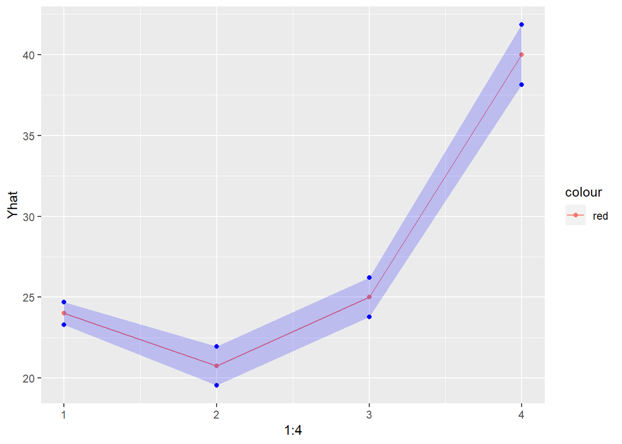

```r
library(ggplot2)
d = as.data.frame(cbind(Yupper, Yhat, Ylower))
ggplot(data = d, aes()) + geom_point(aes(x = 1:4, y = Yhat, col = "red")) +
    geom_line(aes(x = 1:4, y = Yhat, col = "red")) +
geom_ribbon(aes(x = 1:4, ymin = Ylower, ymax = Yupper), linetype = "dashed",
    alpha = 0.2, fill = "blue") + geom_point(aes(x = 1:4, y = Yupper), col = "blue") +
    geom_point(aes(x = 1:4, y = Ylower), col = "blue")
```

### Problem 4) Exercise 10.2 on page 246.

##### an AR model has AR characteristic polynomial

$$(1-1.6x+0.7x^2)(1-0.8x^{12})$$

#### a) is the model stationary?

the process is of the form,

$$(1-\phi_{1}x-\phi_{2}x^2)(1-\Phi_1 x^{12})$$

with $\phi_{1}=1.6$, $\phi_{2}=-0.7$, and $\phi=0.8$

for an AR(2) process, we require that,

$$\phi_{1}+\phi_{2}<1 , \quad \phi_{2}-\phi_{1}<1 , \quad |\phi_{2}|<1 , \quad |\Phi_{1}|<1$$
we check that,

$$\phi_{1}+\phi_{2}= 0.9 < 1 \\
\phi_{2}-\phi_{1}=-2.3 < 1 \\
|\phi_{2}|=0.7<1 \\
|\Phi_{1}|=0.8<1$$

$\Longrightarrow$ the model is stationary

#### b) identify the model

the model is $ARIMA(2,0,0)\times(1,0,0)_{12}$, since there is no MA, seasonal MA, differencing, or seasonal differencing.

### Problem 5) Exercise 10.9 on page 247.

```r
data(airpass)
```

#### a) Display the time series plots of both the original time series and the logarithms of the series. Argue that taking the log is an apporopriate transformation.

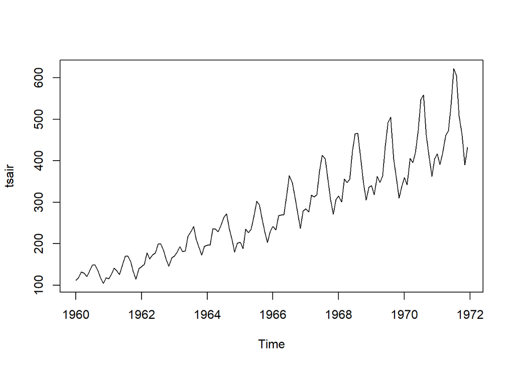

```r
tsair=airpass
plot(tsair)
```

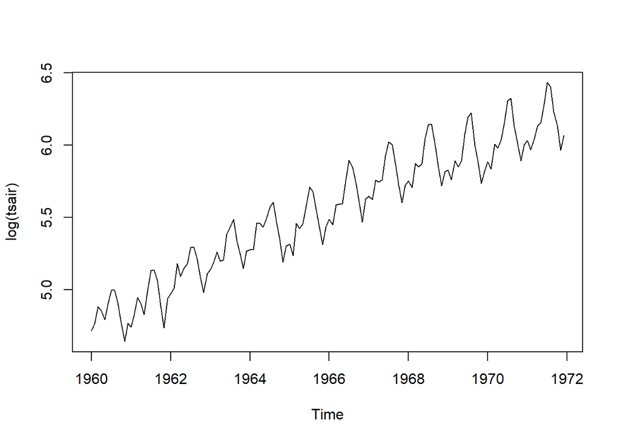

```r
plot(log(tsair))
```

in the original airline data, the variance is increasing with time. The log of the data has no exploding variance, but still has a drift. we will difference the log data to get a perfectly stationary series with constant mean (no drift) and no exploding variance.

#### b) Display and interpret the time series plots of the first difference of the logged series.

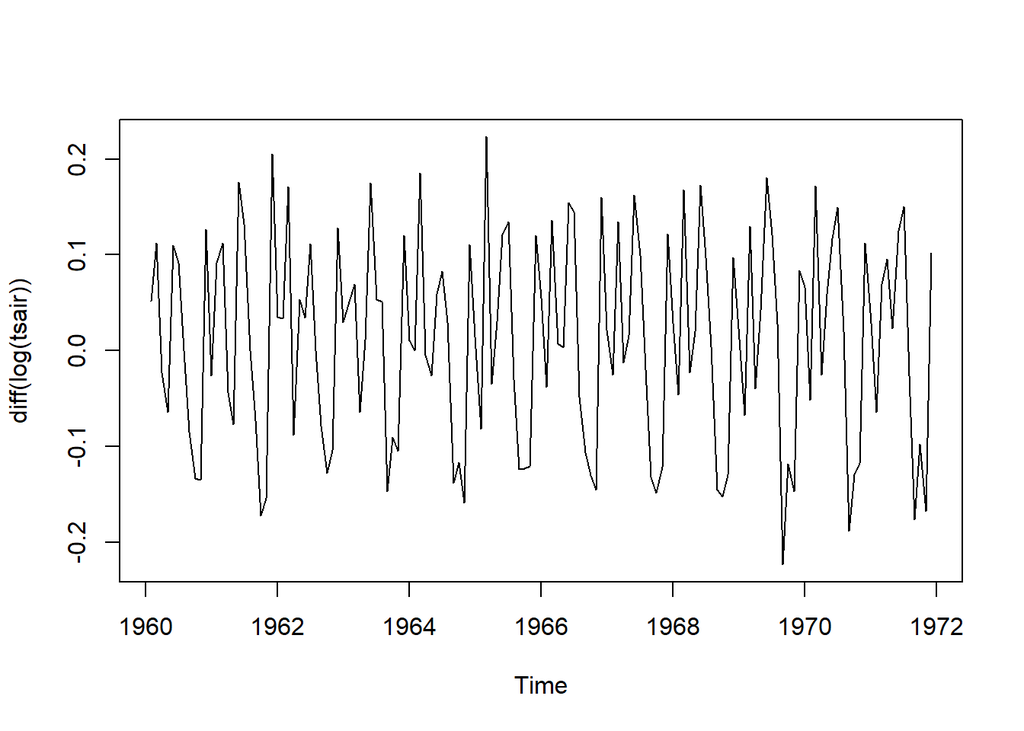

```r
plot(diff(log(tsair)))
```

#### c) Display and interpret the time series plot of the seasonal difference of the first difference of the logged series.

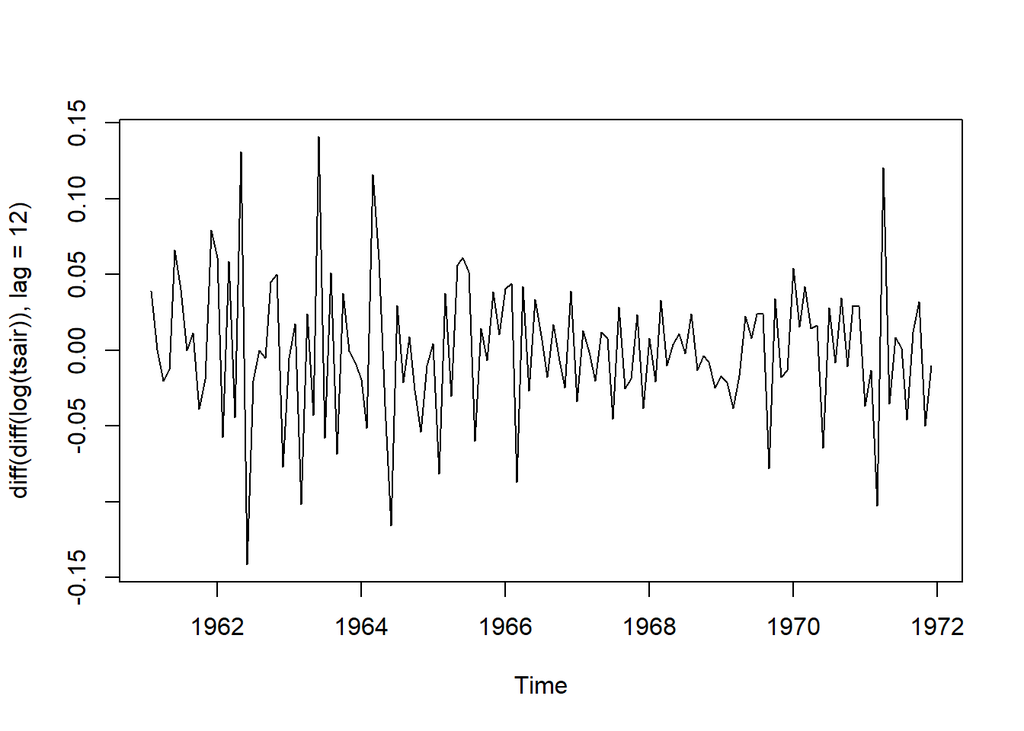

```r
plot(diff(diff(log(tsair)),lag=12))
```

#### d) Calculate and interpret the sample ACF of the seasonal difference of the first difference of the logged series.

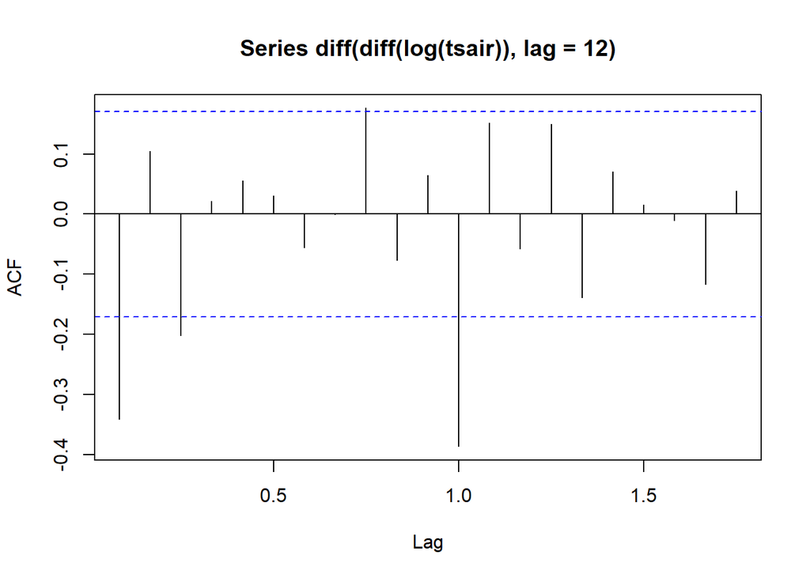

```r
acf(diff(diff(log(tsair)),lag=12))
```

#### e) Fit the ‘airline model’ $(ARIMA(0,1,1)\times(0,1,1)_{12})$ of the logged series.

```r
#m=auto.arima(log(tsair))
m=arima(log(tsair), order = c(0,1,1), seasonal = list(order = c(0,1,1),period=12))
m
```

```
##
## Call:
## arima(x = log(tsair), order = c(0, 1, 1), seasonal = list(order = c(0, 1, 1),
##     period = 12))
##
## Coefficients:
##           ma1     sma1
##       -0.4018  -0.5569
## s.e.   0.0896   0.0731
##
## sigma^2 estimated as 0.001348:  log likelihood = 244.7,  aic = -485.4
```

#### f) Investigate diagnostics for this model, including autocorrelation and normality of the residuals.

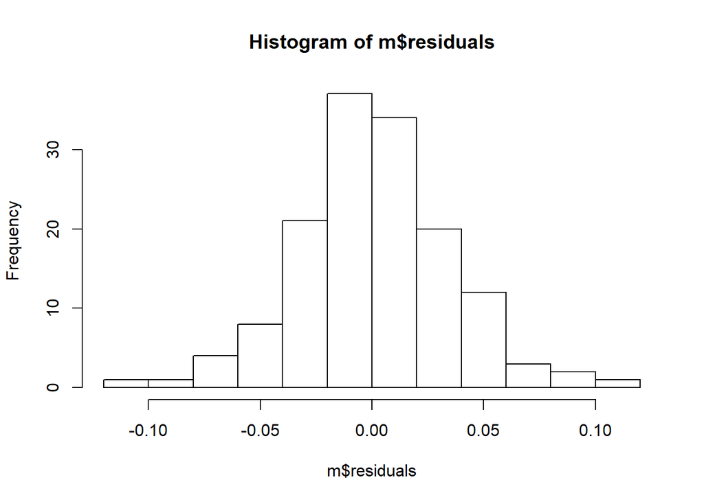

```r
library(nortest)
hist(m$residuals)
```

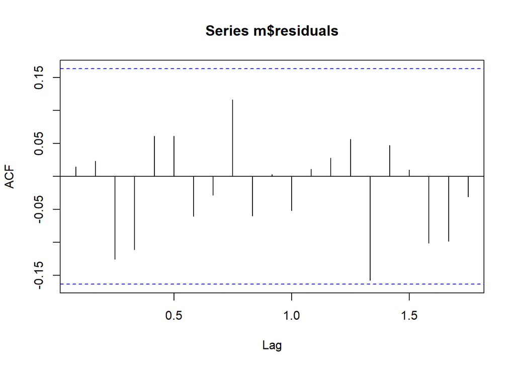

```r
acf(m$residuals)
```

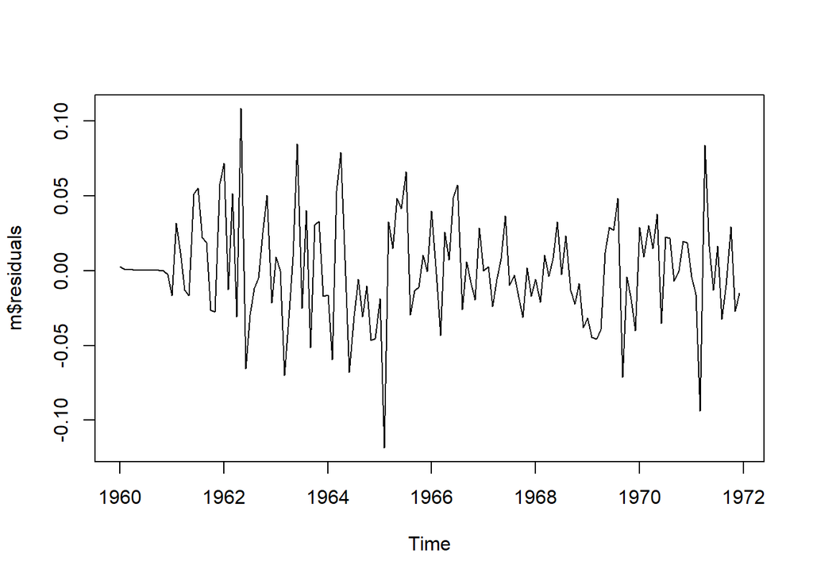

```r
plot(m$residuals)
```

```r
#independence
Box.test(m$residuals,lag=20)
```

```
##
##  Box-Pierce test
##
## data:  m$residuals
## X-squared = 16.062, df = 20, p-value = 0.7128
```

```r
LB.test(m,lag=20,type="Ljung-Box")
```

```
##
##  Box-Ljung test
##
## data:  residuals from  m
## X-squared = 15.976, df = 18, p-value = 0.5942
```

```r
LB.test(m,lag=20,type="Box-Pierce")
```

```
##
##  Box-Pierce test
##
## data:  residuals from  m
## X-squared = 14.388, df = 18, p-value = 0.7034
```

```r
#normality
cvm.test(m$residuals)
```

```
##
##  Cramer-von Mises normality test
##
## data:  m$residuals
## W = 0.12349, p-value = 0.05311
```

```r
lillie.test(m$residuals)
```

```
##
##  Lilliefors (Kolmogorov-Smirnov) normality test
##
## data:  m$residuals
## D = 0.07772, p-value = 0.03307
```

```r
shapiro.test(m$residuals)
```

```
##
##  Shapiro-Wilk normality test
##
## data:  m$residuals
## W = 0.98637, p-value = 0.1674
```

```r
ad.test(m$residuals)
```

```
##
##  Anderson-Darling normality test
##
## data:  m$residuals
## A = 0.68703, p-value = 0.07132
```

```r
library(ggpubr)
```

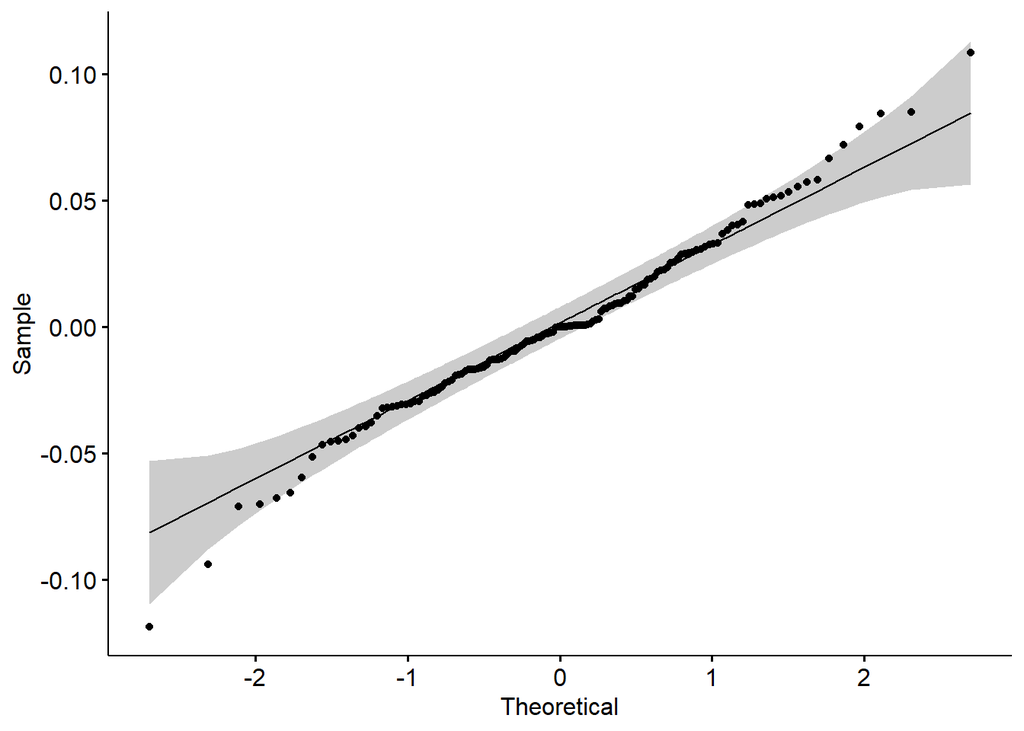

```r
ggqqplot(m$residuals)
```

#### g) Produce forecasts for this time series with a lead time of two years. Be sure to include forecast limits.

TSA plot.Arima worked, but could not run inside of markdown. Was not able to fix it, included an image from R instead.

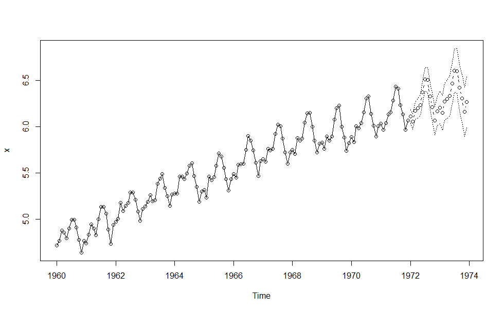

```r
knitr::include_graphics("Rplot.png")
```

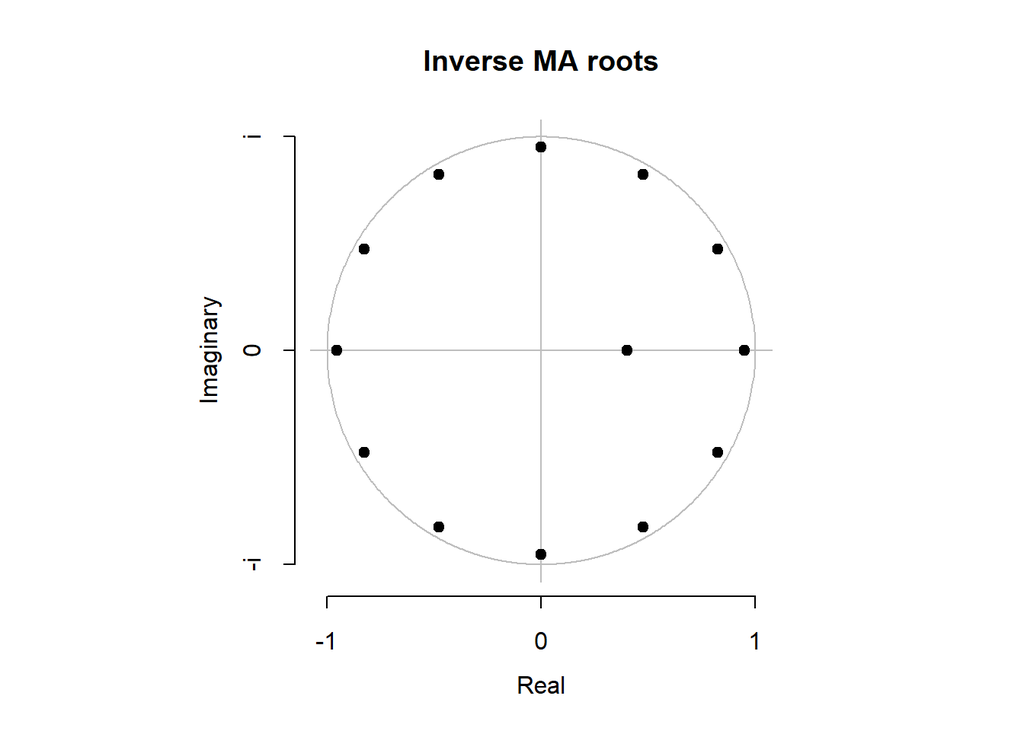

```r
detach(package:forecast)
library(TSA)
plot(m,n.ahead=24)
```

```r
#forec=forecast(m,24)
```